# Project: Investigate The Medical Appointment No Shows Dataset

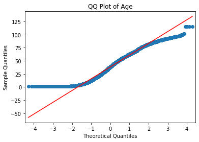

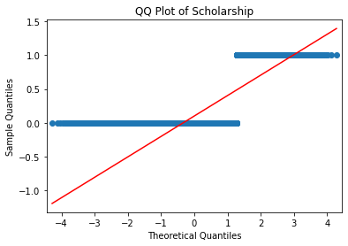

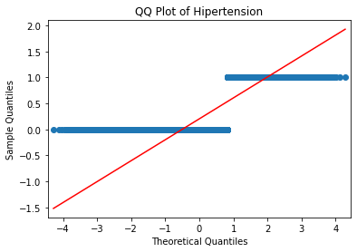

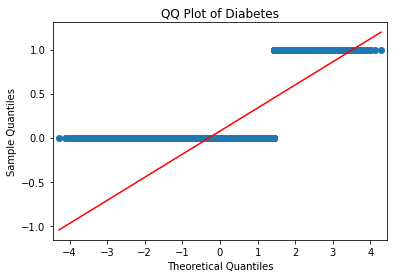

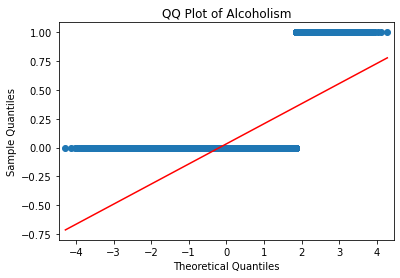

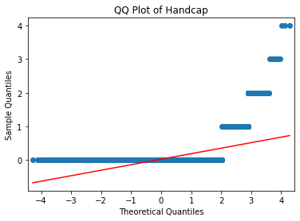

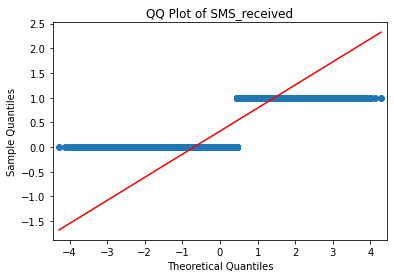

```python
for col in num_cols:
    plt.figure( figsize=(10,5))
    sm.qqplot(data[['{}'.format(col)]].sort_values(['{}'.format(col)]), line='s')
    plt.title("QQ Plot of {}".format(col))
    plt.show()
```

The QQ plot examines where the distribution deviates away from the normal distribution.

#### Age

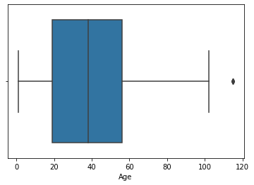

```python
sns.boxplot(x = 'Age', data=data);
```

```python
data['Age'].describe()

bins = [1,19,38,56,115]
labels = ['Child', 'Youth', 'Young Adult', 'Adult']

data['Age-groups'] = pd.cut(data['Age'], bins=bins, labels=labels);
data.head()
```

|  | PatientId | AppointmentID | Gender | ScheduledDay | AppointmentDay | Age | Neighbourhood | Scholarship | Hipertension | Diabetes | Alcoholism | Handcap | SMS_received | No-show | Age-groups |
| --- | --- | --- | --- | --- | --- | --- | --- | --- | --- | --- | --- | --- | --- | --- | --- |
| 0 | 2.987250e+13 | 5642903 | F | 2016-04-29 18:38:08+00:00 | 2016-04-29 00:00:00+00:00 | 62 | JARDIM DA PENHA | 0 | 1 | 0 | 0 | 0 | 0 | No | Adult |
| 1 | 5.589978e+14 | 5642503 | M | 2016-04-29 16:08:27+00:00 | 2016-04-29 00:00:00+00:00 | 56 | JARDIM DA PENHA | 0 | 0 | 0 | 0 | 0 | 0 | No | Young Adult |
| 2 | 4.262962e+12 | 5642549 | F | 2016-04-29 16:19:04+00:00 | 2016-04-29 00:00:00+00:00 | 62 | MATA DA PRAIA | 0 | 0 | 0 | 0 | 0 | 0 | No | Adult |
| 3 | 8.679512e+11 | 5642828 | F | 2016-04-29 17:29:31+00:00 | 2016-04-29 00:00:00+00:00 | 8 | PONTAL DE CAMBURI | 0 | 0 | 0 | 0 | 0 | 0 | No | Child |
| 4 | 8.841186e+12 | 5642494 | F | 2016-04-29 16:07:23+00:00 | 2016-04-29 00:00:00+00:00 | 56 | JARDIM DA PENHA | 0 | 1 | 1 | 0 | 0 | 0 | No | Young Adult |

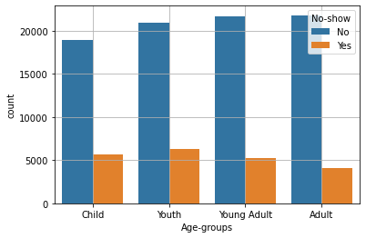

```python
sns.countplot(data['Age-groups'], data=data, hue='No-show');
plt.grid();
```

### Research Question 1 (What is the fraction of patients who miss their scheduled appointment?)

```python
data['No-show'].describe()
```

```
count     106987
unique         2
top           No
freq       85307
Name: No-show, dtype: object
```

```python
data['No-show'].value_counts(normalize=True)
```

```
No     0.797359
Yes    0.202641
Name: No-show, dtype: float64
```

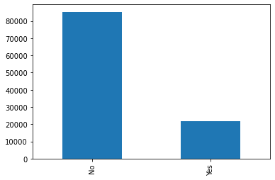

```python
data['No-show'].value_counts().plot(kind='bar')
```

20% of the patients failed to turn up for their booked appointments

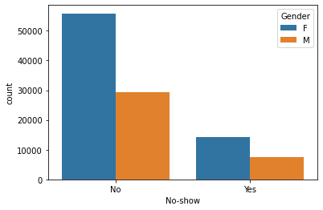

```python
sns.countplot('No-show', data=data, hue='Gender');
```

### Research Question 2 (Which neighbourhood had the highest number of missed appointments?)

```python
data.groupby(['Neighbourhood','No-show']).sum()
```

| Neighbourhood | No-show | PatientId | AppointmentID | Age | Scholarship | Hipertension | Diabetes | Alcoholism | Handcap | SMS_received |
| --- | --- | --- | --- | --- | --- | --- | --- | --- | --- | --- |
| AEROPORTO | No | 2.196900e+14 | 39668533 | 388 | 0 | 2 | 0 | 0 | 0 | 1 |
|  | Yes | 9.598723e+13 | 5595387 | 37 | 0 | 0 | 0 | 0 | 0 | 0 |
| ANDORINHAS | No | 2.440454e+17 | 9579515276 | 63329 | 230 | 460 | 238 | 38 | 75 | 384 |
|  | Yes | 7.963785e+16 | 2882821541 | 18343 | 91 | 126 | 61 | 14 | 16 | 174 |
| ANTÔNIO HONÓRIO | No | 3.036060e+16 | 1202883258 | 8713 | 9 | 5 | 3 | 0 | 1 | 69 |
| ... | ... | ... | ... | ... | ... | ... | ... | ... | ... | ... |
| TABUAZEIRO | Yes | 7.562254e+16 | 3125838850 | 18191 | 102 | 104 | 36 | 8 | 13 | 241 |
| UNIVERSITÁRIO | No | 1.729128e+16 | 677170380 | 5101 | 2 | 34 | 14 | 2 | 3 | 42 |
|  | Yes | 3.318961e+15 | 181383094 | 1289 | 3 | 7 | 3 | 0 | 0 | 12 |
| VILA RUBIM | No | 1.135505e+17 | 3908454314 | 32571 | 60 | 204 | 78 | 10 | 38 | 235 |
|  | Yes | 3.021175e+16 | 785375811 | 5225 | 10 | 29 | 12 | 7 | 4 | 75 |

162 rows × 9 columns

[figure not shown]

```python
hood_count = data[(data['No-show'] == 'Yes')]
hood_count = hood_count.groupby(['Neighbourhood'])['No-show'].value_counts().sort_values(ascending=False)
plt.title('Hoods with the highest turn ups')
plt.ylabel('Count')
hood_count.head(10).plot(kind='bar',figsize=(10,8));
# plt.show()
```

### Research Question 3 (What factors are important for us to know in order to predict if a patient will show up for their scheduled appointment?)

```python
data.groupby(['Gender']).sum()
```

| Gender | PatientId | AppointmentID | Age | Scholarship | Hipertension | Diabetes | Alcoholism | Handcap | SMS_received |
| --- | --- | --- | --- | --- | --- | --- | --- | --- | --- |
| F | 1.019128e+19 | 397875442468 | 2794145 | 8826 | 15339 | 5606 | 1223 | 1403 | 23757 |
| M | 5.565908e+18 | 209322236257 | 1305178 | 1983 | 6462 | 2337 | 2137 | 1055 | 10828 |

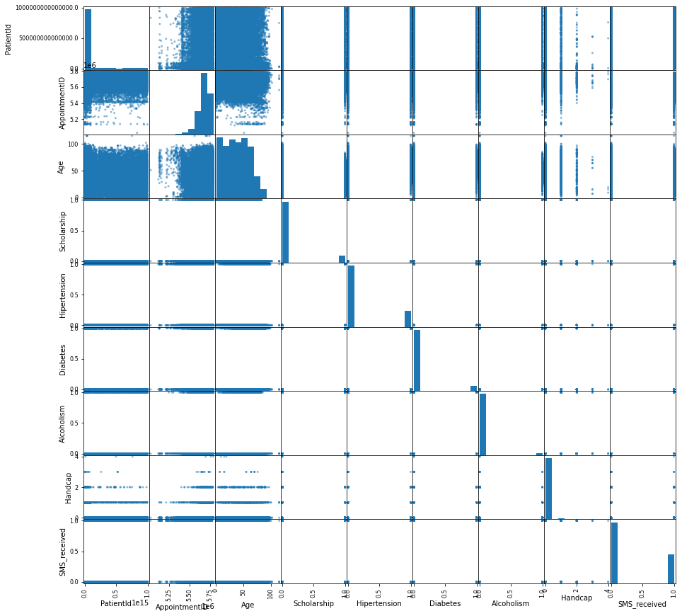

```python
pd.plotting.scatter_matrix(data, figsize=(15,15));
```

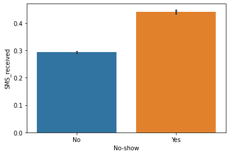

```python
sns.barplot(y='SMS_received', x='No-show', data=data)
```